# Model Selection: Gila Monster Detection

Sienna Solis-Stokes

# Introduction

For this exercise I decided to use my thesis data to create models which best describe Gila monster detection along a transect. I calculated the mean temperature, the median rockiness index (same index from previous assignment), the median elevation, shrub density, and total adult prey species observed (prey presence) along a transect. The data consists of 504 transects across 6 sites.

```
## tibble [504 × 9] (S3: tbl_df/tbl/data.frame)
##  $ date         : chr [1:504] "3/26/2025" "3/26/2025" "3/26/2025" "3/27/2025" ...
##  $ transect_id  : chr [1:504] "FP097" "FP110" "FP119" "WR037" ...
##  $ site_id      : chr [1:504] "fort_pearce" "fort_pearce" "fort_pearce" "white_reef" ...
##  $ rockiness    : num [1:504] 3 5 4 4 5 5 4 4 5 4 ...
##  $ elevation    : num [1:504] 943 942 947 939 978 941 961 988 1000 960 ...
##  $ shrub_density: num [1:504] 0.3739 0.2975 0.3673 0.1162 0.0749 ...
##  $ prey_presence: int [1:504] 1 4 0 1 2 11 2 1 8 0 ...
##  $ air_temp     : num [1:504] 26.1 21.4 21.4 28.1 26.9 ...
##  $ detection    : int [1:504] 0 0 0 0 0 0 0 0 0 0 ...
```

# Multicollinearity

Checked for multicollinearity

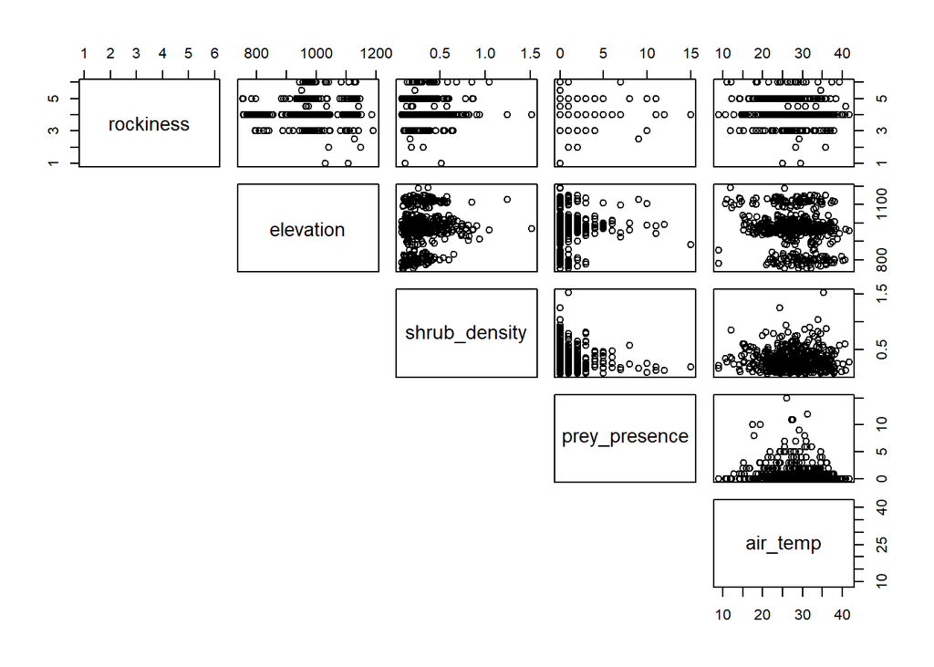

```r
pairs(gm_df[,4:8], lower.panel = NULL)
```

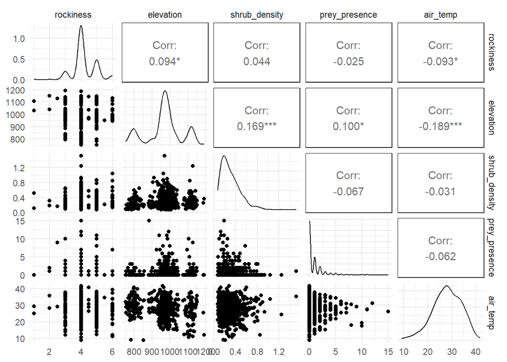

```r
GGally::ggpairs(gm_df, columns = 4:8)
```

I created a global model with all 5 predictor variables and used the performance package to look at the VIF scores.

```r
model_global <- glm(detection ~ rockiness + elevation + air_temp + prey_presence + shrub_density, family = binomial, data = gm_df)

performance::check_collinearity(model_global)
```

```
## # Check for Multicollinearity
##
## Low Correlation
##
##           Term  VIF   VIF 95% CI adj. VIF Tolerance Tolerance 95% CI
##      rockiness 1.05 [1.01, 1.32]     1.03      0.95     [0.75, 0.99]
##      elevation 1.06 [1.01, 1.30]     1.03      0.94     [0.77, 0.99]
##       air_temp 1.10 [1.03, 1.28]     1.05      0.91     [0.78, 0.97]
##  prey_presence 1.04 [1.00, 1.39]     1.02      0.96     [0.72, 1.00]
##  shrub_density 1.02 [1.00, 2.66]     1.01      0.98     [0.38, 1.00]
```

All VIF scores are low (<5) which means there is some correlation but not too severe.

# Model Selection

Next I created 7 models with corresponding biological hypotheses.

```r
model_01 <- glm(detection ~ rockiness + elevation, family = binomial, data = gm_df)
model_02 <- glm(detection ~ rockiness + air_temp, family = binomial, data = gm_df)
model_03 <- glm(detection ~ rockiness + shrub_density, family = binomial, data = gm_df)
model_04 <- glm(detection ~ rockiness + prey_presence, family = binomial, data = gm_df)
model_05 <- glm(detection ~ rockiness + shrub_density + prey_presence, family = binomial, data = gm_df)
model_06 <- glm(detection ~ shrub_density + prey_presence, family = binomial, data = gm_df)
model_07 <- glm(detection ~ rockiness + elevation + air_temp, family = binomial, data = gm_df)
```

Model 1 (rockiness + elevation): Detection probability increases on sandier, lower-elevation transects where thermal conditions and sandier substrates promote above-ground activity and sign visibility.

Model 2 (rockiness + air temp): Detection probability rises on sandier transects and during warmer air temperatures, consistent with greater surface activity and clearer track/visual detectability.

Model 3 (rockiness + shrub density): Detection probability increases on sandier, sparsely vegetated transects (higher visibility/surface activity) and declines on rockier, shrub-dense transects.

Model 4 (rockiness + prey presence): Detection probability increases on sandier transects and where prey are present (nest predators), and foraging activity is easier to detect on loose substrates.

Model 5 (rockiness + shrub density + prey presence): Detection probability is higher on sandier transects when prey are present, but dense shrubs reduce detectability and potential prey-vegetation associations may lead to more foraging activity which could offset reduced detectability.

Model 6 (shrub density + prey presence): Detection probability increases with prey presence and decreases with shrub density due to visual obstruction and more compact substrates.

Model 7 (rockiness + elevation + air temp): Detection probability increases with sandier substrates and warmer temperatures; elevation has an added effect.

Then I compared the models:

```r
model_comparison <- MuMIn::model.sel(model_01, model_02, model_03, model_04, model_05, model_06, model_07)
model_comparison
```

```
## Model selection table
##            (Int)      elv    rck air_tmp shr_dns pry_prs df  logLik  AICc delta
## model_02 -10.440          0.8041  0.1280                  3 -80.213 166.5  0.00
## model_07 -13.740 0.003312 0.7459  0.1387                  4 -79.359 166.8  0.32
## model_01  -7.529 0.001750 0.6144                          3 -84.649 175.3  8.87
## model_03  -6.187          0.6436          0.7478          3 -84.676 175.4  8.93
## model_04  -6.026          0.6582                 0.01787  3 -84.888 175.8  9.35
## model_05  -6.232          0.6464          0.7698 0.02554  4 -84.653 177.4 10.91
## model_06  -3.435                          0.8737 0.01621  3 -86.982 180.0 13.54
##          weight
## model_02  0.530
## model_07  0.450
## model_01  0.006
## model_03  0.006
## model_04  0.005
## model_05  0.002
## model_06  0.001
## Models ranked by AICc(x)
```

model_02 and model_07 were are the strongest supported models; based on AICc scores (and delta values).

Next, I looked at the sum of weights of the variables and the model-averaged coefficients across all models.

```r
MuMIn::sw(model_comparison)
```

```
##                      rockiness air_temp elevation shrub_density prey_presence
## Sum of weights:          1      0.98     0.46     <0.01         <0.01
## N containing models:     6         2        2         3             3
```

```r
MuMIn::model.avg(model_comparison, revised.var = TRUE)
```

```
##
## Call:
## model.avg(object = model_comparison, revised.var = TRUE)
##
## Component models:
## '23'  '123' '12'  '24'  '25'  '245' '45'
##
## Coefficients:
##        (Intercept) rockiness  air_temp   elevation shrub_density prey_presence
## full      -11.8493 0.7741483 0.1302429 0.001502400   0.006834877  0.0001557779
## subset    -11.8493 0.7746193 0.1329243 0.003290539   0.761899621  0.0199651464
```

Then I used the summary function to look at only the competitive model averaged coefficients for the predictor variables

```
##
## Call:
## model.avg(object = model_comparison, subset = delta < 2)
##
## Component model call:
## glm(formula = <2 unique values>, family = binomial, data = gm_df)
##
## Component models:
##     df logLik   AICc delta weight
## 23   3 -80.21 166.47  0.00   0.54
## 123  4 -79.36 166.80  0.32   0.46
##
## Term codes:
## elevation rockiness  air_temp
##         1         2         3
##
## Model-averaged coefficients:
## (full average)
##               Estimate Std. Error Adjusted SE z value Pr(>|z|)
## (Intercept) -11.959705   3.241188    3.247024   3.683  0.00023 ***
## rockiness     0.777342   0.308942    0.309684   2.510  0.01207 *
## air_temp      0.132924   0.045442    0.045551   2.918  0.00352 **
## elevation     0.001522   0.002396    0.002399   0.634  0.52582
##
## (conditional average)
##               Estimate Std. Error Adjusted SE z value Pr(>|z|)
## (Intercept) -11.959705   3.241188    3.247024   3.683  0.00023 ***
## rockiness     0.777342   0.308942    0.309684   2.510  0.01207 *
## air_temp      0.132924   0.045442    0.045551   2.918  0.00352 **
## elevation     0.003312   0.002562    0.002569   1.289  0.19727
## ---
## Signif. codes:  0 '***' 0.001 '**' 0.01 '*' 0.05 '.' 0.1 ' ' 1
```

Thus the supported hypothesis is that Gila monster detection probability increases with warmer air temperatures and sandier substrates with elevation playing a minor role.

# Mixed-effects Models

I wanted to see how (and if) my results would change with mixed-effects models, so I created 7 more identical models that account for the random effect of each transect nested within each site.

```r
gm_df <- gm_df %>%
  mutate(site_id = factor(site_id),
         transect_id = factor(transect_id))

model_08 <- glmer(detection ~ rockiness + elevation + (1|site_id/transect_id), family = binomial, data = gm_df)
model_09 <- glmer(detection ~ rockiness + air_temp + (1|site_id/transect_id), family = binomial, data = gm_df)
model_10 <- glmer(detection ~ rockiness + shrub_density + (1|site_id/transect_id), family = binomial, data = gm_df)
model_11 <- glmer(detection ~ rockiness + prey_presence + (1|site_id/transect_id), family = binomial, data = gm_df)
model_12 <- glmer(detection ~ rockiness + shrub_density + prey_presence  + (1|site_id/transect_id), family = binomial, data = gm_df)
model_13 <- glmer(detection ~ shrub_density + prey_presence + (1|site_id/transect_id), family = binomial, data = gm_df)
model_14 <- glmer(detection ~ rockiness + elevation + air_temp + (1|site_id/transect_id), family = binomial, data = gm_df)
```

Then I looked at the summary tables to compare all 14 models.

```
## Model selection table
##            (Int)      elv    rck air_tmp shr_dns  pry_prs    class  random df
## model_13 -14.850                          0.6668 -0.04760 glmerMod s_i/t_i  5
## model_09 -10.840          0.8205  0.1294                  glmerMod s_i/t_i  5
## model_14 -14.110 0.003339 0.7897  0.1350                  glmerMod s_i/t_i  6
## model_02 -10.440          0.8041  0.1280                       glm          3
## model_07 -13.740 0.003312 0.7459  0.1387                       glm          4
## model_08  -7.674 0.001400 0.6624                          glmerMod s_i/t_i  5
## model_10  -6.476          0.6739          0.3519          glmerMod s_i/t_i  5
## model_11  -6.335          0.6732                 -0.03613 glmerMod s_i/t_i  5
## model_12  -6.415          0.6682          0.3222 -0.03257 glmerMod s_i/t_i  6
## model_01  -7.529 0.001750 0.6144                               glm          3
## model_03  -6.187          0.6436          0.7478               glm          3
## model_04  -6.026          0.6582                  0.01787      glm          3
## model_05  -6.232          0.6464          0.7698  0.02554      glm          4
## model_06  -3.435                          0.8737  0.01621      glm          3
##           logLik  AICc  delta weight
## model_13 -33.329  76.8   0.00      1
## model_09 -76.986 164.1  87.31      0
## model_14 -76.647 165.5  88.68      0
## model_02 -80.213 166.5  89.69      0
## model_07 -79.359 166.8  90.02      0
## model_08 -81.575 173.3  96.49      0
## model_10 -81.589 173.3  96.52      0
## model_11 -81.597 173.3  96.54      0
## model_12 -81.558 175.3  98.51      0
## model_01 -84.649 175.3  98.57      0
## model_03 -84.676 175.4  98.62      0
## model_04 -84.888 175.8  99.05      0
## model_05 -84.653 177.4 100.61      0
## model_06 -86.982 180.0 103.23      0
## Models ranked by AICc(x)
## Random terms:
##  s_i/t_i: 1 | site_id/transect_id
```

When adding in the mixed-effects models, our model comparison results completely change. By taking in to account the random effects of site and transect, the only supported model is model 13 which uses shrub density and prey presence as the predictor variables.

Then I wanted to use the performance package to check the highest ranked GLM model and the highest ranked mixed-effects model.

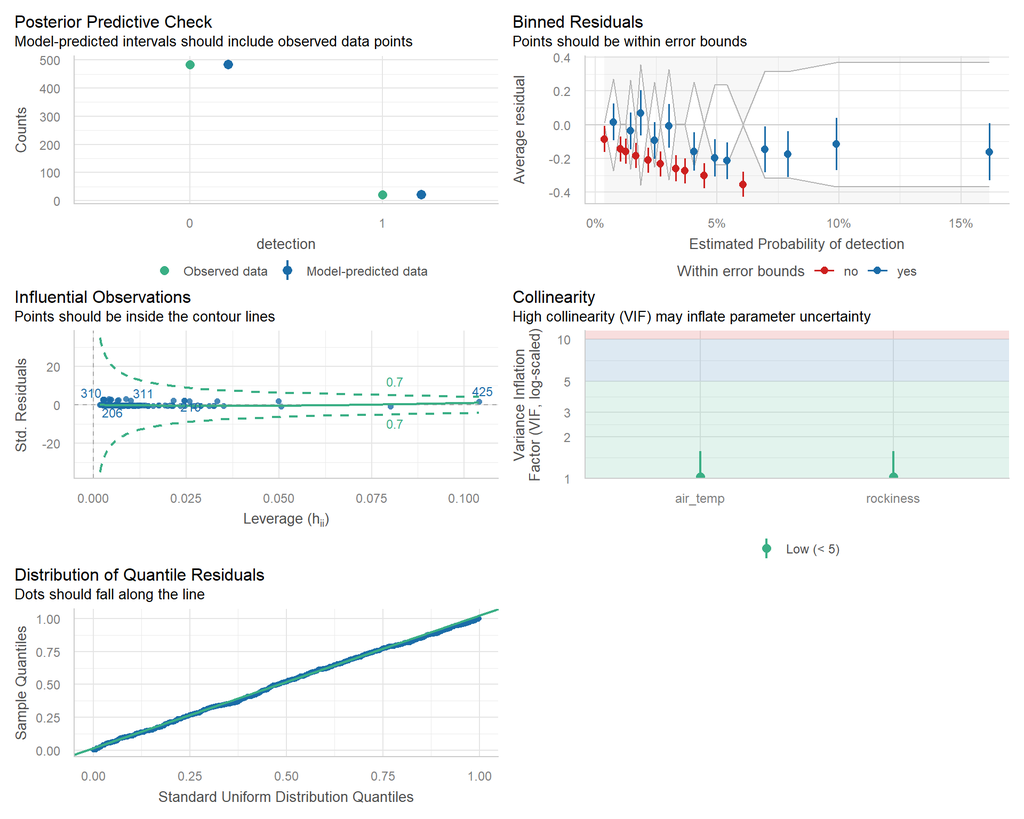

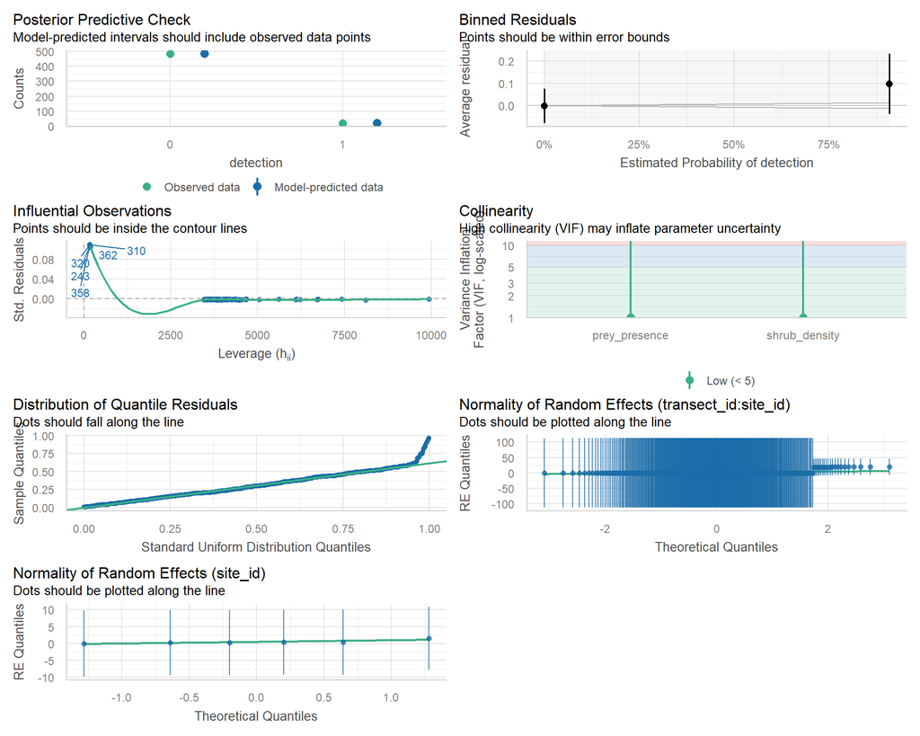

# Variable Plots

Lastly I created variable plots

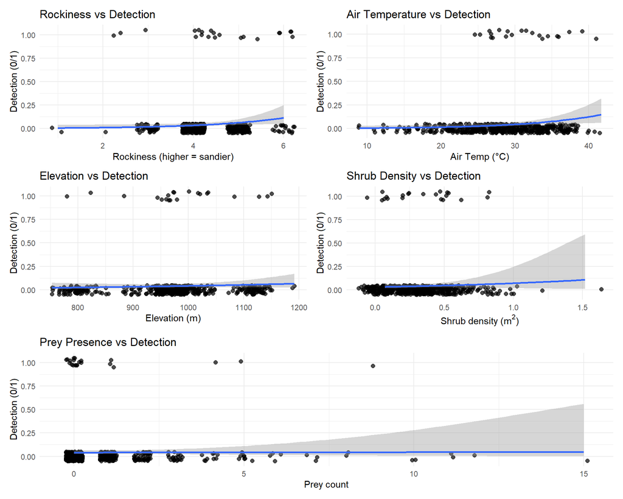